# EasyVisa Project

#### Observations on `case_status`

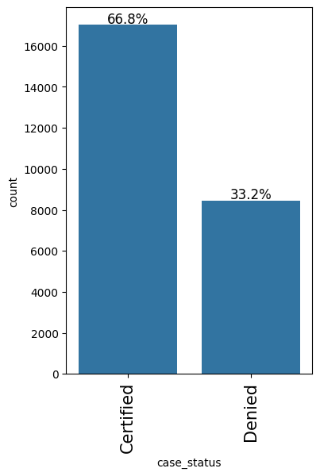

```python
labeled_barplot(data, feature="case_status", perc=True)
```

#### Observations

- Approximately, 66.8% of the cases were approved for visas; while 33.2% were not.

#### Observations on `continent`

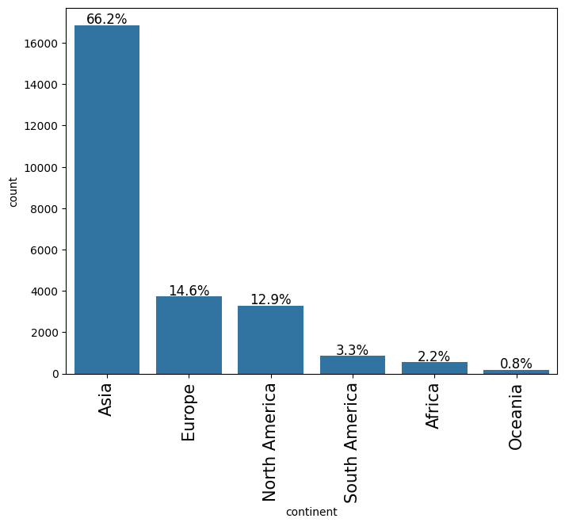

```python
labeled_barplot(data, feature="continent", perc=True)
```

#### Observations

- Approximately, 66.2% of the visa requests were from Asia; followed by Europe with 14.6%.
- North America had approximately 12.9% of the visa requests.

#### Observation on `education_of_employee`

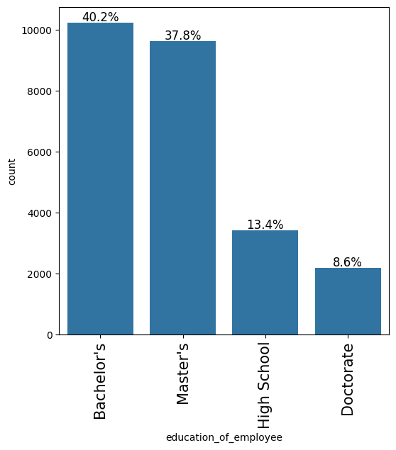

```python
labeled_barplot(data, feature="education_of_employee", perc=True)
```

#### Observations

- Approximately, 40.2% of the requesting employees held a Bachelor's degree.
- Approximately, 37.8% of the requesting employees held a Master's degress.
- Approximately, 13.4% of the requesting employees helf only a High School degree.

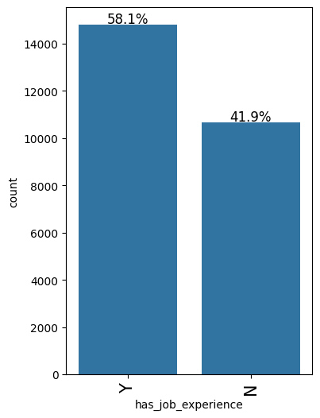

```python
labeled_barplot(data, feature="has_job_experience", perc=True)
```

#### Observations

- The majority (58.1%) of the employees had previoius job experience; while 41.9% did not.

#### Observation on `requires_job_training`

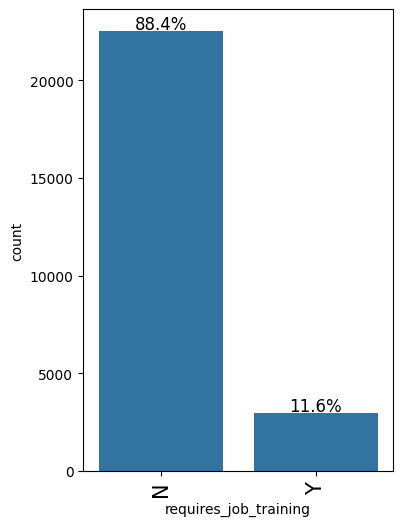

```python
labeled_barplot(data, feature="requires_job_training", perc=True)
```